# Titanic data using Logistic Regression and Random Forest Classifier

## Titanic Dataset

### About Dataset

The data consists of demographic and traveling information for 891 of the Titanic passengers, and the goal is to predict the survival of these passengers.

The Titanic dataset is also the subject of the introductory competition on Kaggle.com.

**INDEX**

- Import Libraries
- Data Overview
- Data Analysing
- Data Cleaning
- Converting Categorical Features
- Numeric Data Analysis
- Building Logistic Regression Model
- Using Ensemble Technique Random Forest Classifier
- Conclusion

## 1) Import Libraries

```python
import numpy as np
import pandas as pd
import matplotlib.pyplot as plt
import seaborn as sns
import warnings
warnings.filterwarnings('ignore')
```

```python
df=pd.read_csv(r'C:\Users\APOORVA\Desktop\MACHINE LEARNING\Recording\19\train (1).csv')
```

## 2) Data Overview

The titanic data set has 891 rows and 12 columns. Summary of Datatypes in datasets are

- 2 float64
- 5 int64
- 5 object

Dependent/Target feature choosen is **Survived** which is integer type.

Columns and their respective datatypes are given below:

1) PassengerId -> int64

2) Survived -> int64

3) Pclass -> int64

4) Name -> object

5) Sex -> object

6) Age -> float64

7) SibSp -> int64

8) Parch -> int64

9) Ticket -> object

10) Fare -> float64

11) Cabin -> object

12) Embarked -> object

In **Age** , **Embarked**, **Cabin** features there are some values missing.

- 177 values from **Age** column is missing
- 687 values from **Cabin** column is missing
- 2 values from **Embarked** column is missing

## 3) Data Analysing

This section discusses how some features are related to target feature.

Here, I have plotted to show how many passengers survived in the titanic incident.

There are 2 plots that shows how **Gender** and **Socio-economic class** affects the **survival** chances.

```python
df.head()
```

|  | PassengerId | Survived | Pclass | Name | Sex | Age | SibSp | Parch | Ticket | Fare | Cabin | Embarked |
| --- | --- | --- | --- | --- | --- | --- | --- | --- | --- | --- | --- | --- |
| 0 | 1 | 0 | 3 | Braund, Mr. Owen Harris | male | 22.0 | 1 | 0 | A/5 21171 | 7.2500 | NaN | S |
| 1 | 2 | 1 | 1 | Cumings, Mrs. John Bradley (Florence Briggs Th... | female | 38.0 | 1 | 0 | PC 17599 | 71.2833 | C85 | C |
| 2 | 3 | 1 | 3 | Heikkinen, Miss. Laina | female | 26.0 | 0 | 0 | STON/O2. 3101282 | 7.9250 | NaN | S |
| 3 | 4 | 1 | 1 | Futrelle, Mrs. Jacques Heath (Lily May Peel) | female | 35.0 | 1 | 0 | 113803 | 53.1000 | C123 | S |
| 4 | 5 | 0 | 3 | Allen, Mr. William Henry | male | 35.0 | 0 | 0 | 373450 | 8.0500 | NaN | S |

```python
df.tail()
```

|  | PassengerId | Survived | Pclass | Name | Sex | Age | SibSp | Parch | Ticket | Fare | Cabin | Embarked |
| --- | --- | --- | --- | --- | --- | --- | --- | --- | --- | --- | --- | --- |
| 886 | 887 | 0 | 2 | Montvila, Rev. Juozas | male | 27.0 | 0 | 0 | 211536 | 13.00 | NaN | S |
| 887 | 888 | 1 | 1 | Graham, Miss. Margaret Edith | female | 19.0 | 0 | 0 | 112053 | 30.00 | B42 | S |
| 888 | 889 | 0 | 3 | Johnston, Miss. Catherine Helen "Carrie" | female | NaN | 1 | 2 | W./C. 6607 | 23.45 | NaN | S |
| 889 | 890 | 1 | 1 | Behr, Mr. Karl Howell | male | 26.0 | 0 | 0 | 111369 | 30.00 | C148 | C |
| 890 | 891 | 0 | 3 | Dooley, Mr. Patrick | male | 32.0 | 0 | 0 | 370376 | 7.75 | NaN | Q |

```python
df.info()
```

```
<class 'pandas.core.frame.DataFrame'>
RangeIndex: 891 entries, 0 to 890
Data columns (total 12 columns):
 #   Column       Non-Null Count  Dtype
---  ------       --------------  -----
 0   PassengerId  891 non-null    int64
 1   Survived     891 non-null    int64
 2   Pclass       891 non-null    int64
 3   Name         891 non-null    object
 4   Sex          891 non-null    object
 5   Age          714 non-null    float64
 6   SibSp        891 non-null    int64
 7   Parch        891 non-null    int64
 8   Ticket       891 non-null    object
 9   Fare         891 non-null    float64
 10  Cabin        204 non-null    object
 11  Embarked     889 non-null    object
dtypes: float64(2), int64(5), object(5)
memory usage: 83.7+ KB
```

```python
df.isna().apply(pd.value_counts).T
```

|  | False | True |
| --- | --- | --- |
| PassengerId | 891.0 | NaN |
| Survived | 891.0 | NaN |
| Pclass | 891.0 | NaN |
| Name | 891.0 | NaN |
| Sex | 891.0 | NaN |
| Age | 714.0 | 177.0 |
| SibSp | 891.0 | NaN |
| Parch | 891.0 | NaN |
| Ticket | 891.0 | NaN |
| Fare | 891.0 | NaN |
| Cabin | 204.0 | 687.0 |
| Embarked | 889.0 | 2.0 |

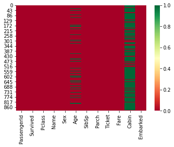

```python
## We can also visualize missing data using seaborn

sns.heatmap(df.isnull(),cmap='RdYlGn')
```

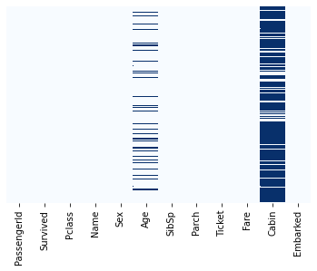

```python
#deleting cbar and yticklabels and using different color
sns.heatmap(df.isnull(),yticklabels=False,cbar=False,cmap='Blues')
plt.show()
```

###### Approximately 20% of Age data is missing and 77% of cabin data is missing.

#### Univariant Analysis

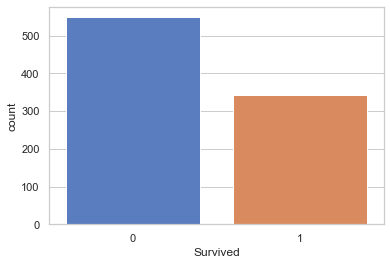

```python
sns.set(style='whitegrid',palette='muted',color_codes=True)
sns.countplot(df.Survived)
plt.show()
```

##### Most of the people died in the Titanic Tragedy , only around 300 people survived.

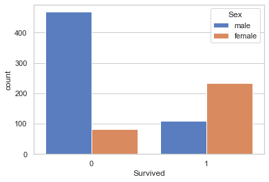

```python
sns.countplot(df.Survived,hue=df.Sex)
plt.show()
```

##### There were more males than females aboard the ship, roughly double the amount. More males died in Titanic Tragedy than females

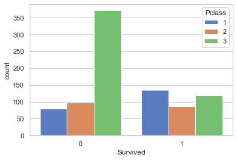

```python
sns.countplot(df.Survived,hue=df.Pclass)
plt.show()
```

##### The majority of the people traveling, had tickets to the 3rd class.

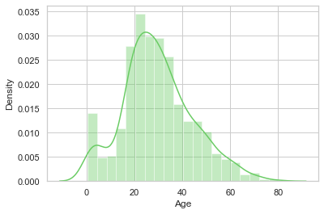

```python
sns.distplot(df.Age,hist=True,kde=True,color='g')
plt.show()
```

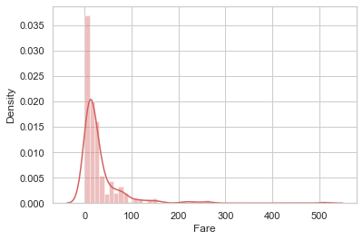

```python
sns.distplot(df.Fare,hist=True,kde=True,color='r')
plt.show()
```

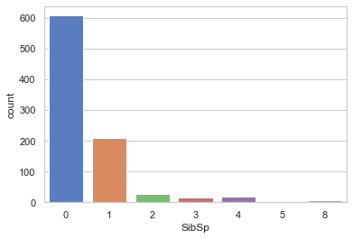

```python
sns.countplot(df.SibSp)
plt.show()
```

## 4) Data Cleaning

We have to fill the missing data in Age Feature. Traditionally we fill calculating mean of all passengers ages (imputation) or We can check average age by passenger class

Median is taken from boxplot and filled in function

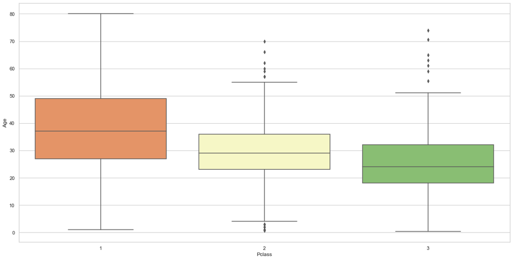

```python
plt.figure(figsize=(20,10))
sns.boxplot(x='Pclass',y='Age',data=df,palette='RdYlGn')
plt.show()
```

##### 1st class = age group is approximately 27 to 49 and 2nd class 23 to 36 and 3rd class 18 to 33

```python
def filling_age(col):
    Age=col[0]
    Pclass=col[1]

    if pd.isnull(Age):

        if Pclass==1:
            return 37

        elif Pclass ==2:
            return 29

        else:
            return 24

    else:
        return Age
```

```python
# Can also use this traditional method
#df['Age'].fillna (df['Age'].mean(),inplace=True)
```

```python
df['Age']=df[['Age','Pclass']].apply(filling_age,axis=1)
```

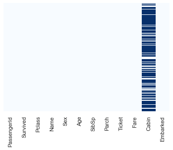

```python
sns.heatmap(df.isnull(),yticklabels=False,cbar=False,cmap='Blues')
plt.show()
```

## 5) Converting Cateogorical Features

Features such ‘Sex’ , ‘Embarked’ is encoded using Label Encoder

Remove Name, Ticket and Cabin feature as they are not useful for prediction

```python
from sklearn.preprocessing import LabelEncoder
```

```python
le=LabelEncoder()
```

```python
df['Sex'].value_counts()
```

```
male      577
female    314
Name: Sex, dtype: int64
```

```python
df['Sex']=le.fit_transform(df['Sex'])
```

```python
df['Sex'].value_counts()
```

```
1    577
0    314
Name: Sex, dtype: int64
```

```python
df['Sex'].value_counts()
```

```
1    577
0    314
Name: Sex, dtype: int64
```

```python
df['Embarked'].value_counts()
```

```
S    644
C    168
Q     77
Name: Embarked, dtype: int64
```

```python
df['Embarked']=le.fit_transform(df['Embarked'])
```

```python
df['Embarked'].value_counts()
```

```
2    644
0    168
1     77
3      2
Name: Embarked, dtype: int64
```

```python
df['Embarked'].fillna (df['Embarked'].mean(),inplace=True)
```

## 6) Numeric Data Analysis

```python
df.head()
```

|  | PassengerId | Survived | Pclass | Name | Sex | Age | SibSp | Parch | Ticket | Fare | Cabin | Embarked |
| --- | --- | --- | --- | --- | --- | --- | --- | --- | --- | --- | --- | --- |
| 0 | 1 | 0 | 3 | Braund, Mr. Owen Harris | 1 | 22.0 | 1 | 0 | A/5 21171 | 7.2500 | NaN | 2 |
| 1 | 2 | 1 | 1 | Cumings, Mrs. John Bradley (Florence Briggs Th... | 0 | 38.0 | 1 | 0 | PC 17599 | 71.2833 | C85 | 0 |
| 2 | 3 | 1 | 3 | Heikkinen, Miss. Laina | 0 | 26.0 | 0 | 0 | STON/O2. 3101282 | 7.9250 | NaN | 2 |
| 3 | 4 | 1 | 1 | Futrelle, Mrs. Jacques Heath (Lily May Peel) | 0 | 35.0 | 1 | 0 | 113803 | 53.1000 | C123 | 2 |
| 4 | 5 | 0 | 3 | Allen, Mr. William Henry | 1 | 35.0 | 0 | 0 | 373450 | 8.0500 | NaN | 2 |

```python
df=df.drop(['PassengerId','SibSp','Parch'],axis=1)
df
```

|  | Survived | Pclass | Name | Sex | Age | Ticket | Fare | Cabin | Embarked |
| --- | --- | --- | --- | --- | --- | --- | --- | --- | --- |
| 0 | 0 | 3 | Braund, Mr. Owen Harris | 1 | 22.0 | A/5 21171 | 7.2500 | NaN | 2 |
| 1 | 1 | 1 | Cumings, Mrs. John Bradley (Florence Briggs Th... | 0 | 38.0 | PC 17599 | 71.2833 | C85 | 0 |
| 2 | 1 | 3 | Heikkinen, Miss. Laina | 0 | 26.0 | STON/O2. 3101282 | 7.9250 | NaN | 2 |
| 3 | 1 | 1 | Futrelle, Mrs. Jacques Heath (Lily May Peel) | 0 | 35.0 | 113803 | 53.1000 | C123 | 2 |
| 4 | 0 | 3 | Allen, Mr. William Henry | 1 | 35.0 | 373450 | 8.0500 | NaN | 2 |
| ... | ... | ... | ... | ... | ... | ... | ... | ... | ... |
| 886 | 0 | 2 | Montvila, Rev. Juozas | 1 | 27.0 | 211536 | 13.0000 | NaN | 2 |
| 887 | 1 | 1 | Graham, Miss. Margaret Edith | 0 | 19.0 | 112053 | 30.0000 | B42 | 2 |
| 888 | 0 | 3 | Johnston, Miss. Catherine Helen "Carrie" | 0 | 24.0 | W./C. 6607 | 23.4500 | NaN | 2 |
| 889 | 1 | 1 | Behr, Mr. Karl Howell | 1 | 26.0 | 111369 | 30.0000 | C148 | 0 |
| 890 | 0 | 3 | Dooley, Mr. Patrick | 1 | 32.0 | 370376 | 7.7500 | NaN | 1 |

891 rows × 9 columns

```python
df.shape
```

```
(891, 9)
```

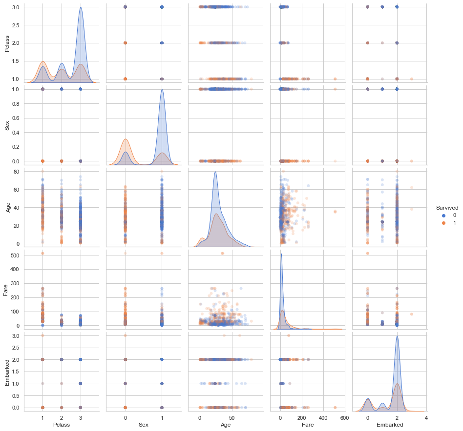

```python
sns.pairplot(df,hue='Survived',plot_kws=dict(alpha=0.2,edgecolor='none'))
```

```python
df.skew()
```

```
Survived    0.478523
Pclass     -0.630548
Sex        -0.618921
Age         0.548256
Fare        4.787317
Embarked   -1.246689
dtype: float64
```

Fare is highy skewed

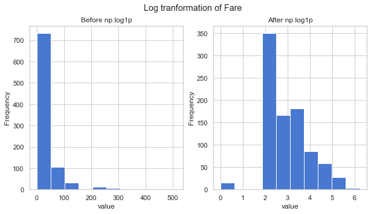

```python
fig,(ax_before,ax_after)=plt.subplots(1,2,figsize=(10,5))
df['Fare'].hist(ax=ax_before)
df['Fare'].apply(np.log1p).hist(ax=ax_after)
ax_before.set(title='Before np.log1p',ylabel='Frequency',xlabel='value')
ax_after.set(title='After np.log1p',ylabel='Frequency',xlabel='value')
fig.suptitle('Log tranformation of Fare')
plt.show()
```

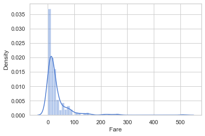

```python
sns.distplot(df.Fare,hist=True,kde=True,color='b')
plt.show()
```

```python
df['Fare1'] = df['Fare'].apply(np.log1p)
```

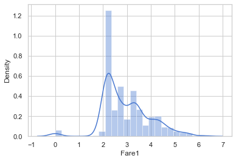

```python
sns.distplot(df.Fare1,hist=True,kde=True,color='b')
plt.show()
```

```python
first_fares=df['Fare'][df['Pclass']==1]
third_fares =df["Fare"][df["Pclass"]==3]
```

```python
first_class_fare=pd.DataFrame(first_fares)
```

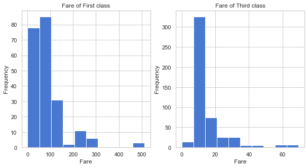

```python
fig,ax=plt.subplots(1,2,figsize=(10,5))
ax[0].hist(first_fares)
ax[0].set_title('Fare of First class')
ax[0].set_xlabel('Fare')
ax[0].set_ylabel('Frequency')
ax[1].hist(third_fares)
ax[1].set_title('Fare of Third class')
ax[1].set_ylabel('Frequency')
ax[1].set_xlabel('Fare')
plt.show()
```

```python
first_fares.mean(),first_fares.median()
```

```
(84.15468749999992, 60.287499999999994)
```

```python
third_fares.mean(),third_fares.median()
```

```
(13.675550101832997, 8.05)
```

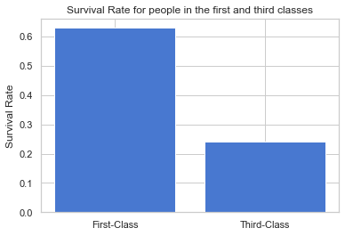

```python
x = ["First-Class", "Third-Class"]
y = [np.mean(df["Survived"][df["Pclass"]==1]), np.mean(df["Survived"][df["Pclass"]==3])]
plt.bar(x, y)
plt.ylabel("Survival Rate")
plt.title("Survival Rate for people in the first and third classes")
plt.show()
```

We can see in the above plot that First Class passengers had Higher Survival Rate than third Class passengers

## 7) Building logistic Regression Model

### Train Test Split

```python
from sklearn.model_selection import train_test_split
```

```python
corr=df.corr()
corr
```

|  | Survived | Pclass | Sex | Age | Fare | Embarked | Fare1 |
| --- | --- | --- | --- | --- | --- | --- | --- |
| Survived | 1.000000 | -0.338481 | -0.543351 | -0.047255 | 0.257307 | -0.163517 | 0.329862 |
| Pclass | -0.338481 | 1.000000 | 0.131900 | -0.408487 | -0.549500 | 0.157112 | -0.661022 |
| Sex | -0.543351 | 0.131900 | 1.000000 | 0.078421 | -0.182333 | 0.104057 | -0.263276 |
| Age | -0.047255 | -0.408487 | 0.078421 | 1.000000 | 0.123784 | -0.006734 | 0.145547 |
| Fare | 0.257307 | -0.549500 | -0.182333 | 0.123784 | 1.000000 | -0.221226 | 0.787543 |
| Embarked | -0.163517 | 0.157112 | 0.104057 | -0.006734 | -0.221226 | 1.000000 | -0.197567 |
| Fare1 | 0.329862 | -0.661022 | -0.263276 | 0.145547 | 0.787543 | -0.197567 | 1.000000 |

```python
corr[['Survived']]
```

|  | Survived |
| --- | --- |
| Survived | 1.000000 |
| Pclass | -0.338481 |
| Sex | -0.543351 |
| Age | -0.047255 |
| Fare | 0.257307 |
| Embarked | -0.163517 |
| Fare1 | 0.329862 |

```python
X=df.drop(['Name','Fare','Ticket','Cabin','Survived'],axis=1)
X
```

|  | Pclass | Sex | Age | Embarked | Fare1 |
| --- | --- | --- | --- | --- | --- |
| 0 | 3 | 1 | 22.0 | 2 | 2.110213 |
| 1 | 1 | 0 | 38.0 | 0 | 4.280593 |
| 2 | 3 | 0 | 26.0 | 2 | 2.188856 |
| 3 | 1 | 0 | 35.0 | 2 | 3.990834 |
| 4 | 3 | 1 | 35.0 | 2 | 2.202765 |
| ... | ... | ... | ... | ... | ... |
| 886 | 2 | 1 | 27.0 | 2 | 2.639057 |
| 887 | 1 | 0 | 19.0 | 2 | 3.433987 |
| 888 | 3 | 0 | 24.0 | 2 | 3.196630 |
| 889 | 1 | 1 | 26.0 | 0 | 3.433987 |
| 890 | 3 | 1 | 32.0 | 1 | 2.169054 |

891 rows × 5 columns

```python
y=df[['Survived']]
y
```

|  | Survived |
| --- | --- |
| 0 | 0 |
| 1 | 1 |
| 2 | 1 |
| 3 | 1 |
| 4 | 0 |
| ... | ... |
| 886 | 0 |
| 887 | 1 |
| 888 | 0 |
| 889 | 1 |
| 890 | 0 |

891 rows × 1 columns

```python
X_train,X_test,y_train,y_test=train_test_split(X,y,test_size=0.3,random_state=1)
```

```python
X_train.shape
```

```
(623, 5)
```

```python
X_test.shape
```

```
(268, 5)
```

```python
y_train.shape
```

```
(623, 1)
```

```python
y_test.shape
```

```
(268, 1)
```

```python
from sklearn.linear_model import LogisticRegression
```

```python
model=LogisticRegression()
```

```python
# Training Logistic Regression model with training data
model.fit(X_train,y_train)
```

```
LogisticRegression()
```

#### Model Evaluation

```python
y_pred=model.predict(X_test)
y_pred
```

```
array([1, 0, 1, 1, 1, 0, 0, 1, 1, 1, 0, 1, 0, 0, 1, 0, 0, 0, 0, 1, 0, 0,
       1, 0, 1, 0, 1, 1, 0, 1, 1, 0, 0, 1, 0, 1, 0, 0, 1, 0, 1, 1, 1, 0,
       1, 0, 0, 0, 0, 0, 0, 1, 0, 0, 0, 1, 0, 0, 0, 1, 1, 0, 0, 0, 0, 1,
       0, 0, 1, 0, 0, 0, 0, 0, 1, 0, 1, 0, 0, 1, 0, 0, 0, 0, 1, 0, 0, 0,
       1, 1, 0, 0, 0, 1, 0, 1, 0, 1, 0, 0, 1, 0, 0, 1, 1, 0, 0, 0, 0, 0,
       0, 0, 0, 0, 0, 0, 0, 0, 1, 0, 1, 0, 0, 0, 1, 1, 1, 1, 0, 0, 0, 0,
       1, 1, 0, 1, 1, 0, 0, 1, 1, 0, 1, 1, 0, 1, 0, 0, 0, 0, 1, 0, 0, 1,
       0, 0, 0, 0, 1, 0, 0, 0, 1, 0, 0, 1, 1, 0, 0, 0, 1, 1, 1, 0, 1, 0,
       0, 0, 1, 0, 1, 1, 0, 0, 1, 0, 0, 1, 0, 1, 0, 0, 1, 1, 1, 1, 0, 1,
       0, 0, 0, 1, 0, 0, 0, 1, 1, 0, 0, 0, 1, 0, 0, 0, 0, 0, 0, 1, 1, 0,
       0, 0, 0, 0, 0, 0, 1, 1, 1, 0, 0, 0, 0, 0, 0, 1, 1, 1, 1, 0, 0, 0,
       0, 0, 0, 0, 1, 1, 0, 1, 0, 0, 0, 1, 1, 1, 0, 1, 0, 1, 1, 0, 1, 1,
       0, 0, 1, 0], dtype=int64)
```

```python
from sklearn.metrics import accuracy_score,classification_report,confusion_matrix
```

```python
accuracy_score(y_test,y_pred)
```

```
0.7649253731343284
```

```python
model.score(X_train,y_train)
```

```
0.8041733547351525
```

```python
print(classification_report(y_test,y_pred))
```

```
              precision    recall  f1-score   support

           0       0.77      0.84      0.80       153
           1       0.75      0.67      0.71       115

    accuracy                           0.76       268
   macro avg       0.76      0.75      0.76       268
weighted avg       0.76      0.76      0.76       268
```

```python
from sklearn.metrics import precision_score, recall_score
print("Precision:", precision_score(y_test,y_pred))
print("Recall:",recall_score(y_test,y_pred))
```

```
Precision: 0.7549019607843137
Recall: 0.6695652173913044
```

```python
from sklearn.metrics import f1_score
f1_score(y_test,y_pred)
```

```
0.7096774193548386
```

##### Our model predicts 75% of the time, a passengers survival correctly (precision). The recall tells us that it predicted the survival of 67% of the people who actually survived.

```python
cf=confusion_matrix(y_test,y_pred)
cf
```

```
array([[128,  25],
       [ 38,  77]], dtype=int64)
```

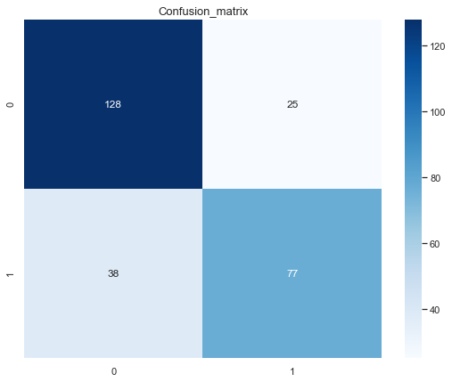

```python
plt.figure(figsize=(9,7))
plt.title('Confusion_matrix',fontsize=13)
sns.heatmap(cf,cmap='Blues',annot=True,fmt='g')
plt.show()
```

### 8) Using Ensemble Technique Random Forest Classifier

```python
from sklearn.ensemble import RandomForestClassifier
```

```python
rf=RandomForestClassifier(n_estimators=100,max_depth=12,criterion='entropy')
```

```python
rf.fit(X_train,y_train)
```

```
RandomForestClassifier(criterion='entropy', max_depth=12)
```

```python
rf_pred=rf.predict(X_test)
```

```python
accuracy_score(y_test,rf_pred)
```

```
0.7873134328358209
```

```python
rf.score(X_train,y_train)
```

```
0.9727126805778491
```

```python
print(classification_report(y_test,rf_pred))
```

```
              precision    recall  f1-score   support

           0       0.76      0.92      0.83       153
           1       0.85      0.62      0.71       115

    accuracy                           0.79       268
   macro avg       0.80      0.77      0.77       268
weighted avg       0.80      0.79      0.78       268
```

```python
print("Precision:", precision_score(y_test,rf_pred))
print("Recall:",recall_score(y_test,rf_pred))
```

```
Precision: 0.8452380952380952
Recall: 0.6173913043478261
```

```python
f1_score(y_test,rf_pred)
```

```
0.7135678391959798
```

Our model predicts 84% of the time, a passengers survival correctly (precision). The recall tells us that it predicted the survival of 61% of the people who actually survived.

```python
cf1=confusion_matrix(y_test,rf_pred)
cf1
```

```
array([[140,  13],
       [ 44,  71]], dtype=int64)
```

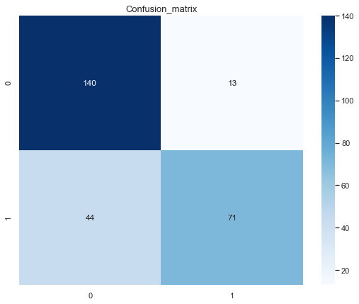

```python
plt.figure(figsize=(9,7))
plt.title('Confusion_matrix',fontsize=13)
sns.heatmap(cf1,cmap='Blues',annot=True,fmt='g')
plt.show()
```

### 9) Conclusion

- Accuracy of data using Logistic Regression is 76% and for Random Forest Classifier accuracy is 78%.
- Precision is high using Random Forest Classifier but recall is high using Logistic Regression. However, F1 score that is harmonic mean of precison recall is almost same for both Random Forest Classifier and Logistic Regression